# WineMag Data

Marlin Helsel

4/23/2019

Let’s look at the data a little closer:

```r
summary(wine$points)
```

```
##    Min. 1st Qu.  Median    Mean 3rd Qu.    Max.
##   80.00   86.00   88.00   88.45   91.00  100.00
```

```r
summary(wine$country)
```

```
##                                     Argentina                Armenia
##                     63                   3800                      2
##              Australia                Austria Bosnia and Herzegovina
##                   2329                   3345                      2
##                 Brazil               Bulgaria                 Canada
##                     52                    141                    257
##                  Chile                  China                Croatia
##                   4472                      1                     73
##                 Cyprus         Czech Republic                  Egypt
##                     11                     12                      1
##                England                 France                Georgia
##                     74                  22093                     86
##                Germany                 Greece                Hungary
##                   2165                    466                    146
##                  India                 Israel                  Italy
##                      9                    505                  19540
##                Lebanon             Luxembourg              Macedonia
##                     35                      6                     12
##                 Mexico                Moldova                Morocco
##                     70                     59                     28
##            New Zealand                   Peru               Portugal
##                   1419                     16                   5691
##                Romania                 Serbia               Slovakia
##                    120                     12                      1
##               Slovenia           South Africa                  Spain
##                     87                   1401                   6645
##            Switzerland                 Turkey                Ukraine
##                      7                     90                     14
##                Uruguay                     US
##                    109                  54504
```

```r
summary(wine$price)
```

```
##    Min. 1st Qu.  Median    Mean 3rd Qu.    Max.    NA's
##  -24.00   16.00   25.00   33.86   42.00 3300.00    8996
```

Lets get rid of the rows without a price or a negative price and limit the the countries that have more than 1000 reviews and take a look at the data again:

```r
summary(dropNas$points)
```

```
##    Min. 1st Qu.  Median    Mean 3rd Qu.    Max.
##   80.00   86.00   88.00   88.51   91.00  100.00
```

```r
summary(dropNas$country)
```

```
##    Argentina    Australia      Austria        Chile       France
##         3514         2177         2658         4041        16905
##      Germany        Italy  New Zealand     Portugal South Africa
##         2036        16179         1273         4551         1208
##        Spain           US
##         6136        52379
```

```r
summary(dropNas$price)
```

```
##    Min. 1st Qu.  Median    Mean 3rd Qu.    Max.
##    4.00   18.00   27.00   36.45   45.00 3300.00
```

This data looks much better to work with. Lets graph this to see what it looks like:

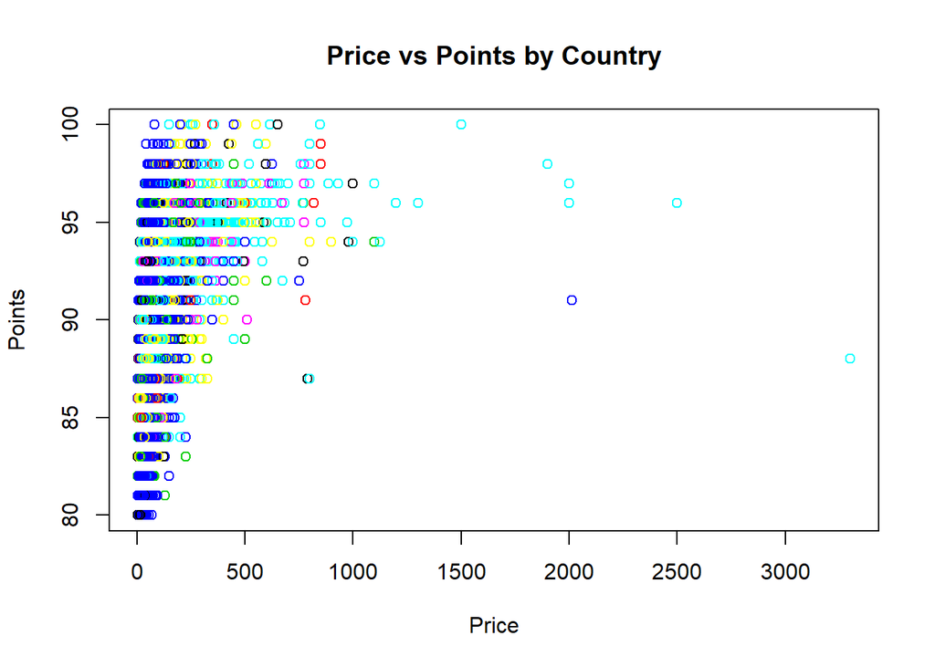

There is not much insight from the data in this graph. There are no trends immediately visable.

Lets look at a linear model predicting points based on the price of the wine.

```r
winelm = lm(points~price, data = dropNas)

summary(winelm)
```

```
##
## Call:
## lm(formula = points ~ price, data = dropNas)
##
## Residuals:
##     Min      1Q  Median      3Q     Max
## -98.993  -1.833   0.016   1.986  10.262
##
## Coefficients:
##              Estimate Std. Error t value Pr(>|t|)
## (Intercept) 8.741e+01  1.095e-02  7979.9   <2e-16 ***
## price       3.018e-02  1.969e-04   153.3   <2e-16 ***
## ---
## Signif. codes:  0 '***' 0.001 '**' 0.01 '*' 0.05 '.' 0.1 ' ' 1
##
## Residual standard error: 2.782 on 113055 degrees of freedom
## Multiple R-squared:  0.172,  Adjusted R-squared:  0.172
## F-statistic: 2.349e+04 on 1 and 113055 DF,  p-value: < 2.2e-16
```

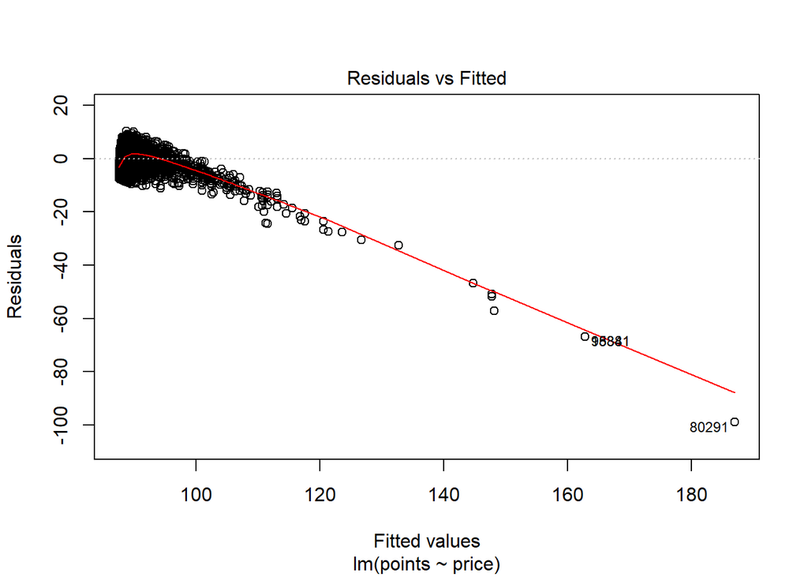

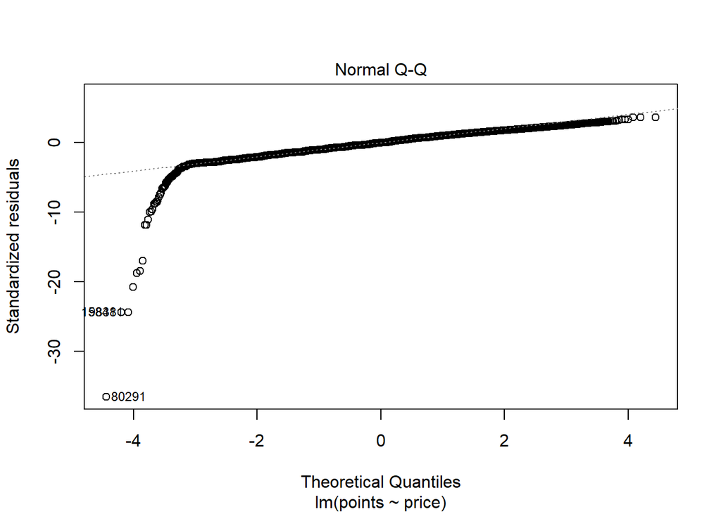

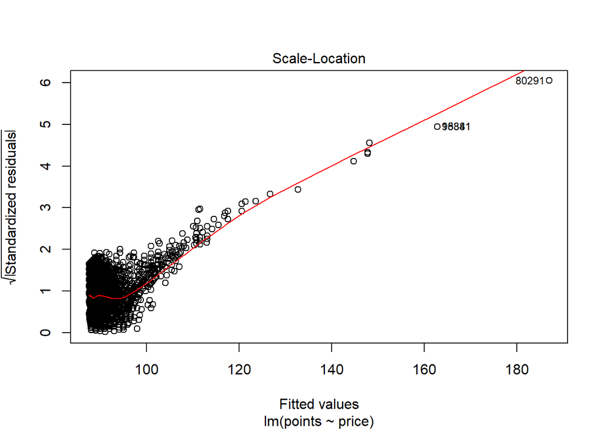

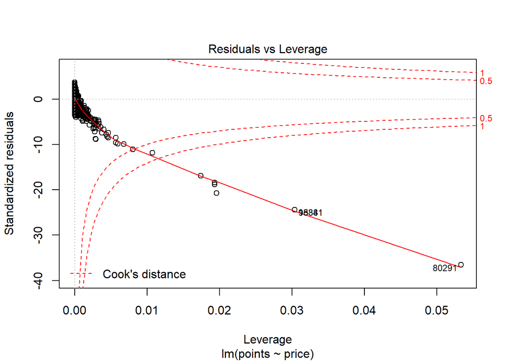

```r
plot(winelm)
```

And lets compare that to the linear model predicting points based on log(price),

```r
logWineLm = lm(points~ log(price), data= dropNas)

summary(logWineLm)
```

```
##
## Call:
## lm(formula = points ~ log(price), data = dropNas)
##
## Residuals:
##      Min       1Q   Median       3Q      Max
## -14.0984  -1.5105   0.1271   1.7203   9.2369
##
## Coefficients:
##             Estimate Std. Error t value Pr(>|t|)
## (Intercept) 78.95148    0.03738  2112.2   <2e-16 ***
## log(price)   2.85706    0.01096   260.6   <2e-16 ***
## ---
## Signif. codes:  0 '***' 0.001 '**' 0.01 '*' 0.05 '.' 0.1 ' ' 1
##
## Residual standard error: 2.417 on 113055 degrees of freedom
## Multiple R-squared:  0.3753, Adjusted R-squared:  0.3753
## F-statistic: 6.791e+04 on 1 and 113055 DF,  p-value: < 2.2e-16
```

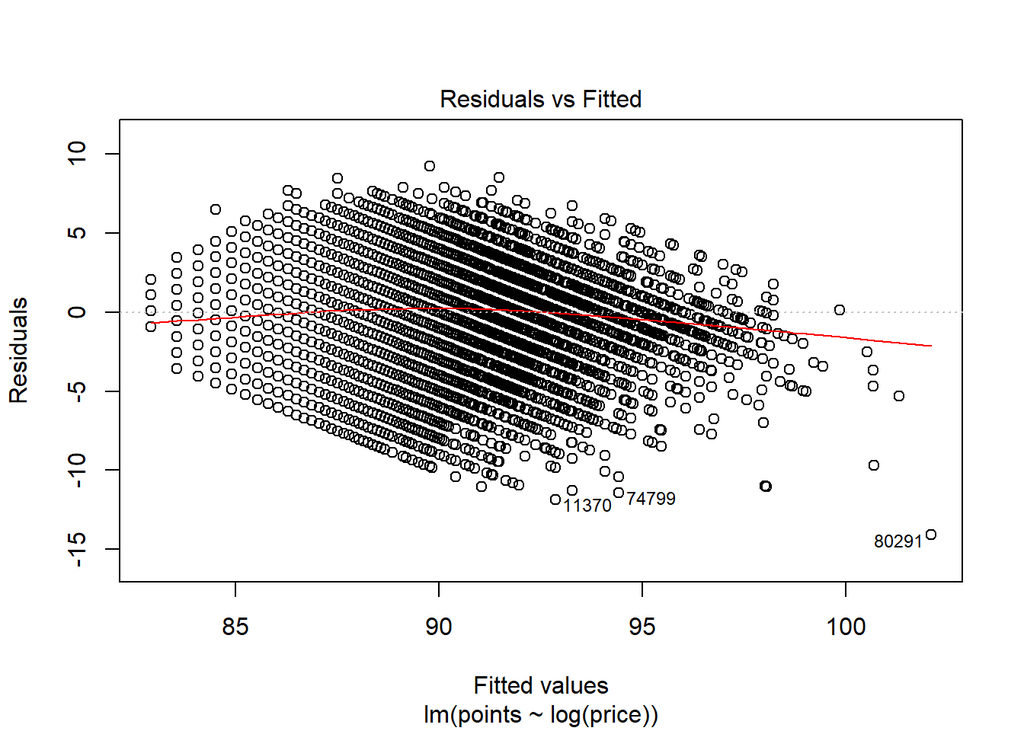

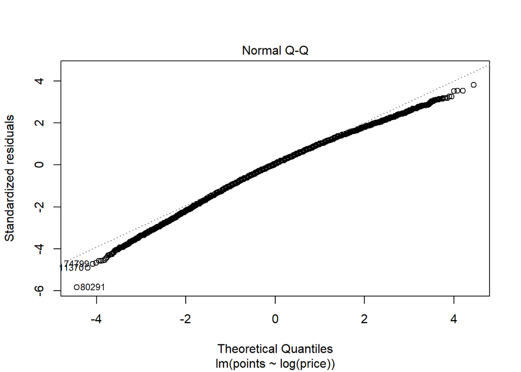

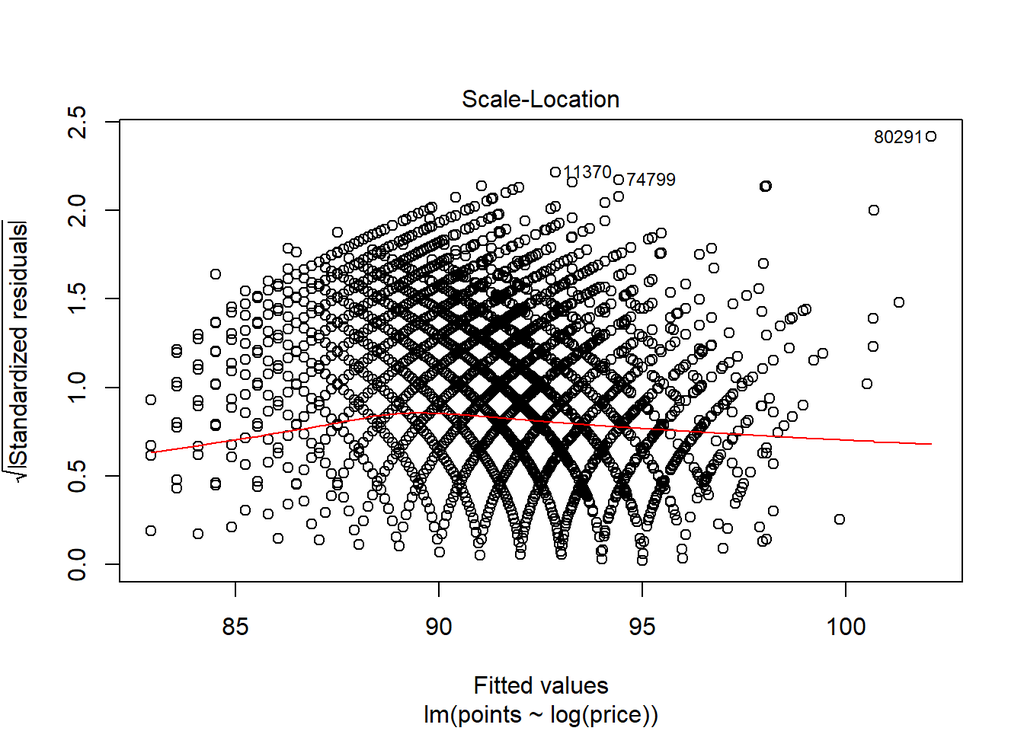

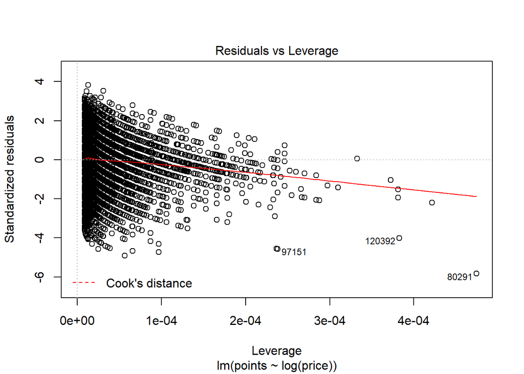

```r
plot(logWineLm)
```

While Comparing these two models, I believe that the second model(predicting points from the log of price) is the better model.

In the Residuals vs Fitted plot, both models have a linear pattern, but the second model has a horizontal trend right around y=0, while the first model has a decreasing trend line moving away from y=0.

In the normal Q-Q plots, both have a mostly linear trend, but the first model has a tail that deviates from this trend at x=-3 and the second model keeps its linear trend throughout.

Again While looking at the Scale-Location plots, model 2 is the better model. Model 2’s data is nicely spread out and shows an almost linear line.

The Residuals vs Leverage plots again strengthen my stance that the second model is a better model to use to predict points. The first model has a handful of points beyond the cook’s distance that are influencing this model and may be outliers. However, the second model has zero points beyond cook’s distance and the is again mostly linear.

Finally, The R-squared value for the second model is 37.5% while the R-squared value for the first model is 17.2%. Meaning that the second model explains more of the variablity in the data around the mean.

This is the best results I could write up within the alloted time. If I had a little longer I would layout the above graphs so they are next to their counterpart for easier visualization while comparing the two. I would have also looked into the data more to see if all of the data that was removed due to their price values needed to be removed or if any of those rows could have been salvaged.